# Logistic regression for classification

Day 14

## Classification models

- Last class we had a very simple rule for classifying “Good Loan” vs “Bad Loan”: whether \(\text{Credit amount} > \$X\)
  - Not based on any optimization
- Today: We start working with classification models optimized to fit the data

## Logistic Regression Model

- We have a set of \(p\) explanatory (predictor) variables \(X_1, ..., X_p\)
- We have a binary response \(Y\) (1/0, yes/no, success/failure)
- Given a set of predictor values \(X_1, ..., X_p\), the response is a Bernoulli random variable with success probability (What are the parameters here?) \[ \pi(X) = \dfrac{e^{\beta_0 + \beta_1 X_1 + ... + \beta_p X_p}}{1+e^{\beta_0 + \beta_1 X_1 + ... + \beta_p X_p}} \]
- This is the *logistic* function that maps the predictor space (\(R^p\)) to a probability in \((0,1)\)
- Estimates of \(\beta\) parameters are found using MLE methods:

\[ L(\beta) = \prod_{i=1}^n \pi(x_i)^{y_i}(1-\pi(x_i))^{1-y_i} \]

## Logistic Regression and odds

- To interpret the effect of a predictor \(X\) on \(Y\) (or \(\pi\)), we can use some algebra to show:

\[ \log\left( \dfrac{\pi(X)}{1-\pi(X)} \right) = \beta_0 + \beta_1 X_1 + ... + \beta_p X_p \]

- The left-hand side is called the **log-odds** (logit) of success. The **odds** of success is just the ratio of the probability of success and failure
- Holding all other predictors constant,
  - a one-unit increase in \(X_1\) is associated with a \(\beta_1\) unit change (additive) in the log-odds of success.
- While effects may be hard to compute, the sign is always easy to interpret

## Visualizing a logistic regression model

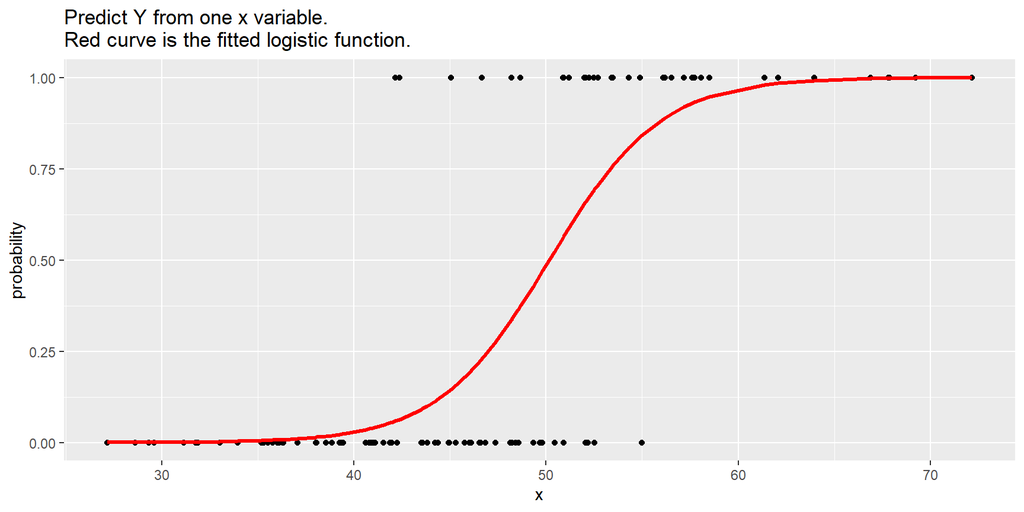

## Visualizing a logistic regression model

- Predict success for any estimated probability > 0.5:

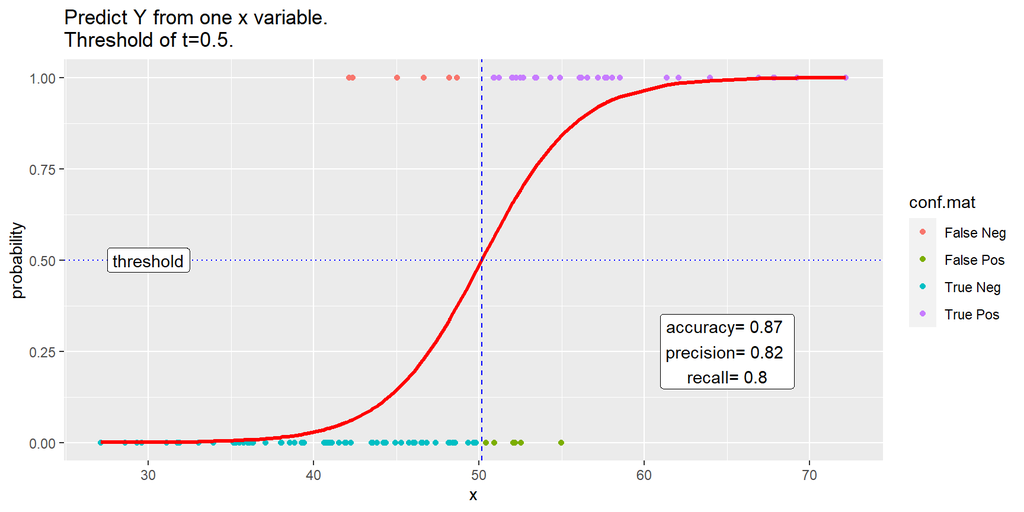

## Visualizing a logistic regression model

- Predict success for any estimated probability > 0.25 (how should that affect our metrics?)

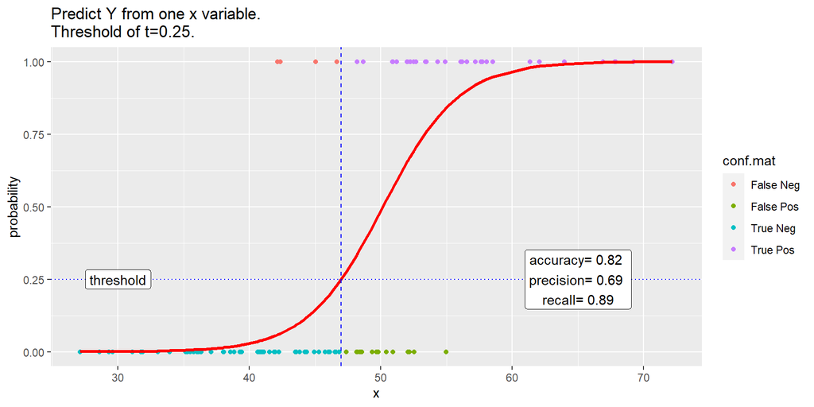

## Fitting a logistic regression model

- The basic R command is

```
my.glm <- glm(Y ~ X1 + X2, data=, family=binomial)
```

- To get predicted probabilities \(\hat{\pi}\) for each case in the data:

```
predict(my.glm, type="response")
```

- Important note: in the `glm` command, `Y` can either be a 1/0 variable or a factor (character) variable
  - 1/0 coded: the `glm` defines \(\pi\) as the probability of `Y=1`
  - factor coded: the `glm` defines \(\pi\) as the probability of the **second** level of `Y`

## Loans example (fit the model)

- First I created a new response with `Default` as the second level:

```r
> loans <- read_csv("https://raw.githubusercontent.com/mgelman/data/master/CreditData.csv")
> loans <- loans %>%
+   mutate(Default = recode_factor(Good.Loan, GoodLoan = "NoDefault",BadLoan = "Default" ))
> table(loans$Good.Loan, loans$Default)

           NoDefault Default
  BadLoan          0     300
  GoodLoan       700       0
```

- The I fit the glm:

```r
> default.glm1 <- glm(Default ~ log(Credit.amount) + Duration.in.month,
+                     family="binomial", data=loans)
```

## Loans example

```r
> summary(default.glm1)

Call:
glm(formula = Default ~ log(Credit.amount) + Duration.in.month,
    family = "binomial", data = loans)

Deviance Residuals:
    Min       1Q   Median       3Q      Max
-1.4729  -0.8364  -0.7158   1.2692   1.9688

Coefficients:
                    Estimate Std. Error z value Pr(>|z|)
(Intercept)        -0.700258   0.844603  -0.829    0.407
log(Credit.amount) -0.139691   0.120620  -1.158    0.247
Duration.in.month   0.043327   0.007627   5.681 1.34e-08 ***
---
Signif. codes:  0 '***' 0.001 '**' 0.01 '*' 0.05 '.' 0.1 ' ' 1

(Dispersion parameter for binomial family taken to be 1)

    Null deviance: 1221.7  on 999  degrees of freedom
Residual deviance: 1175.8  on 997  degrees of freedom
AIC: 1181.8

Number of Fisher Scoring iterations: 4
```

## Loans example (prob estimation)

- The probability of default is estimated to be:

\[ \hat{\pi} = \dfrac{e^{-0.700-0.140ln(Credit) + 0.0433Duration}}{1 + e^{-0.700-0.140ln(Credit) + 0.0433Duration}}\]

## Loans example (add predictions)

- Add the estimated probabilities and predicted responses to the data frame using a 0.5 threshold:

```r
> loans <- loans %>%
+   mutate(probs1 = predict(default.glm1, type="response"),
+          prediction1 = ifelse( probs1 >= .5, "Default", "NoDefault") )
> loans %>% select(Default, probs1, prediction1) %>% print(n=4)
# A tibble: 1,000 × 3
  Default   probs1 prediction1
  <fct>      <dbl> <chr>
1 NoDefault  0.194 NoDefault
2 Default    0.541 Default
3 NoDefault  0.223 NoDefault
4 NoDefault  0.467 NoDefault
# … with 996 more rows
```

## Loans example (confusion matrix and rates)

```r
> with(loans,table(Default,prediction1))
           prediction1
Default     Default NoDefault
  NoDefault      30       670
  Default        39       261
>
> (stats <- loans %>% summarize(accuracy = mean(Default == prediction1),
+             precision = sum(Default == "Default" &  prediction1 == "Default")/sum(prediction1 == "Default"),
+             recall = sum(Default == "Default" &
+                      prediction1 == "Default")/sum(Default == "Default")) )
# A tibble: 1 × 3
  accuracy precision recall
     <dbl>     <dbl>  <dbl>
1    0.709     0.565   0.13
```

- With a threshold of 50%, we are underpredicting the number of loans that will default (very low recall). Good from a consumer perspective, bad for the banker!

## Loans example (visualization)

- the black line is the boundary between default and no default predictions using a threshold of 0.5.

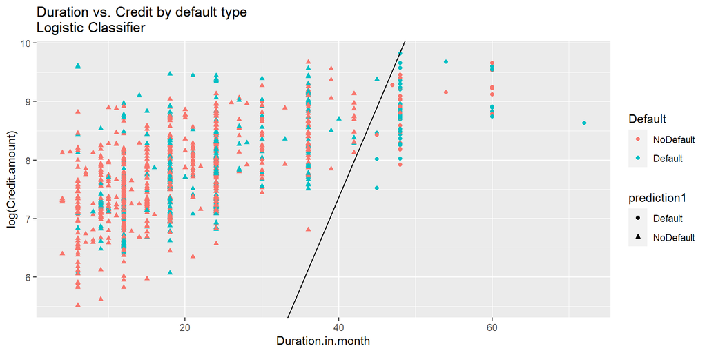

## Loans example

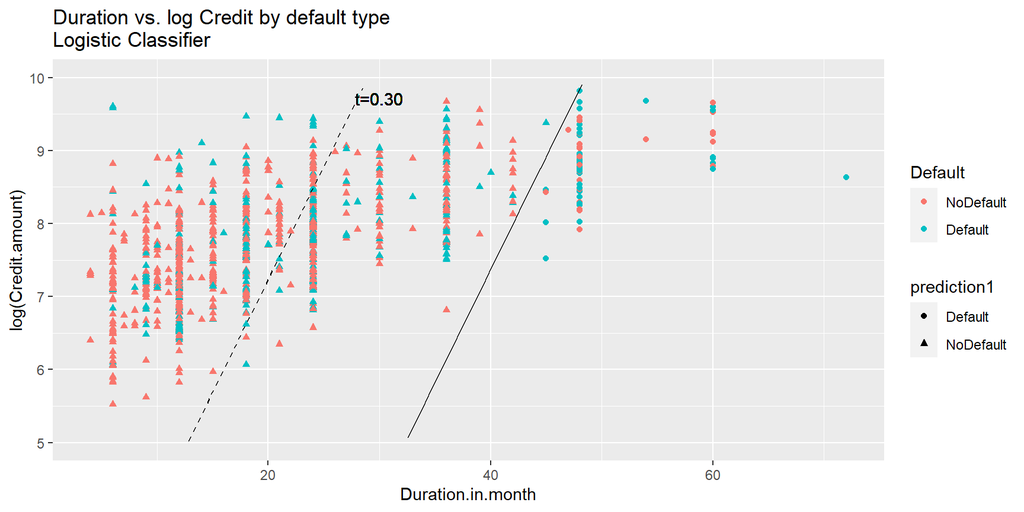

## Evaluating probability (forecasting) models

- **Double density curves**: Plot two density curves for the estimated probabilities \(\hat{p}\):
  - for all true successes (\(Y=1\))
  - for all true failures (\(Y=0\))
- a “good” model will see little overlap between these curves
  - true successes curve will be close to \(\hat{p}\)’s of 1
  - true failures curve will be close to \(\hat{p}\)’s of 0
- can be used to pick/explain classifier thresholds

## Loan defaults: double densities

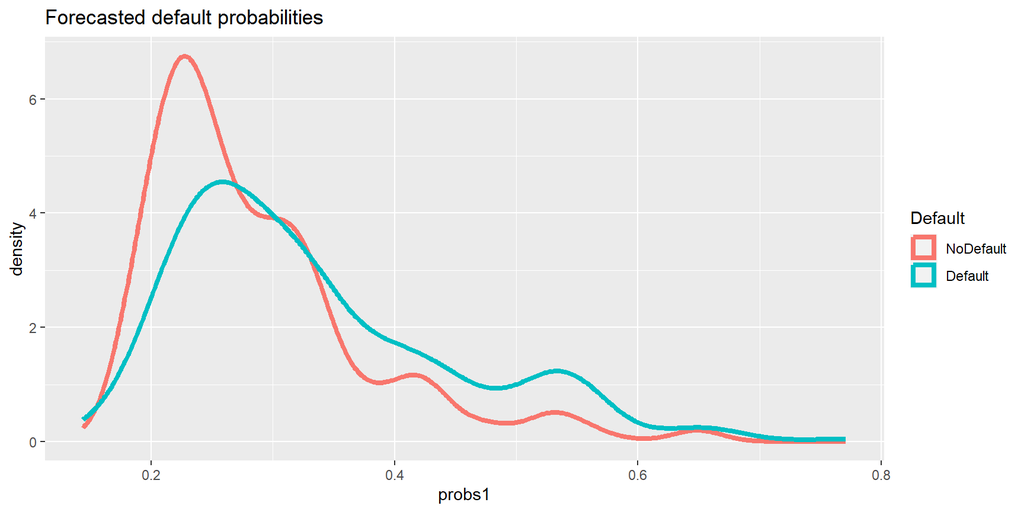

```r
> ggplot(loans, aes(x=probs1, color=Default)) +
+   geom_density(size=1.5) + ggtitle("Forecasted default probabilities")
```

## More ideal double density

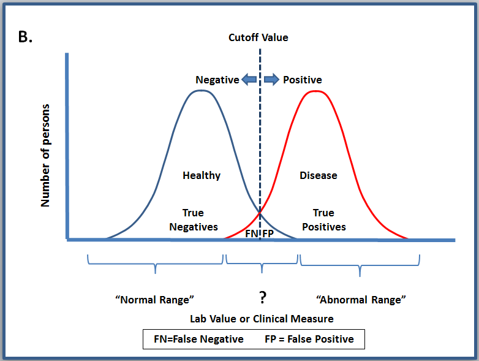

## Evaluating probability (forecasting) models

- **ROC**: A receiver operating characteristic curve varies the threshold value \(t\) of a classifier, then plots:
  - x = false positive rate \(\frac{FP}{n_0}=\frac{FP}{TN + FP}\)
  - y = true positive rate \(\frac{TP}{n_1}=\frac{TP}{TP + FN}\) (recall)
- Idea: As we loosen the threshold (low \(t\)), both \(TP\) and \(FP\) rate should increase
  - What is the relative increase?

## ROC curve

- You could calculate everything manually but the `ROCR` package helps automate it
  - `prediction(probs, y, label.ordering=)` creates a prediction object of probabilities and responses
  - `performance(pred, rates)` computes performance rates for a range of threshold values
- `label.ordering` is a vector of (negative,positive) labels in `y`
- if response `y` is binary (0/1) then `label.ordering` is not needed (1=positive)

```r
> str(loans$Default)
 Factor w/ 2 levels "NoDefault","Default": 1 2 1 1 2 1 1 1 1 2 ...
```

- Need to tell it the ordering or else it will think “NoDefault” is “positive”

## Loan defaults: `ROC` curve

- Can plot ROC curve directly from performance object:

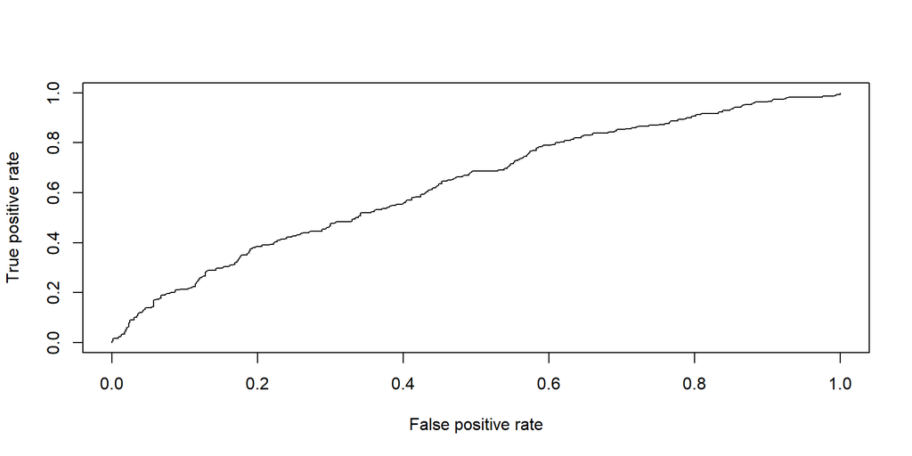

```r
> plot(perf_obj)
```

## Loan defaults: `ROC` curve

- Or create using ggplot by saving rates in a data frame:

```r
> perf_df <- data_frame(fpr=unlist(perf_obj@x.values),
+                        tpr= unlist(perf_obj@y.values),
+                        threshold=unlist(perf_obj@alpha.values),
+                        model="GLM1")
> head(perf_df,n=3)
# A tibble: 3 × 4
    fpr     tpr threshold model
  <dbl>   <dbl>     <dbl> <chr>
1     0 0         Inf     GLM1
2     0 0.00333     0.771 GLM1
3     0 0.00667     0.663 GLM1
> ggplot(perf_df, aes(x=fpr, y=tpr, color=threshold)) +  geom_line() +
+   labs(x="false positive rate", y="true positive rate", title="ROC curve for logistic") +
+   geom_abline(slope=1,intercept=0, linetype=3) +
+   scale_color_gradient2(midpoint=0.5, mid="black", low="orange", high="pink")
```

## Loan defaults: `ROC` curve

[figure not shown]

- ROC curves with area = 1 under the curve (AUC) are perfect classifiers
- ROC curves with area = 0.5 AUC are just as good as random guesses

## `ROC` curve example

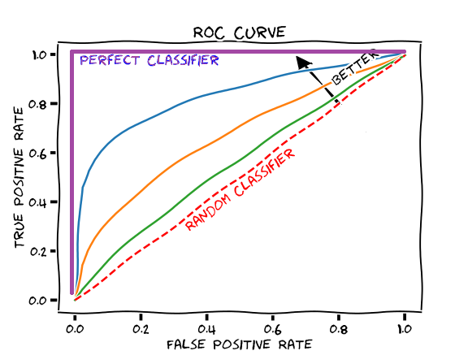

## Summary

- Defined a logistic model
- Estimated a logistic model
- Discussed the impacts of changing the threshold
- Introduced two more evaluation metrics
  - Double density plot
  - ROC curve
- Today’s activity: estimating a model with more variables